# Question 1

Luisa Kalkert, Luke Richard, Nicholas Chandler

2025-07-02

# Introduction

In this section, we ask the question: “How does GDP per capita relate to selected quality of life and human-geographic metrics?”

We begin the analysis by reading in the data (and filtering the relevant columns) as is done in the following R code.

```r
# Function to display the columns and nan counts
col_names_and_nas <- function(df) {
  for (i in seq_along(df)) {
    cat(colnames(df)[i], ":", sum(is.na(df[[i]])), "\n")
  }
}

# read data
full_df <- read.csv("../data/clean_data.csv", header = TRUE)

# Trim data
cols_to_keep <- c("Geography..Map.references", "Geography..Geographic.coordinates", "Geography..Area...land", "Geography..Area...total", "Geography..Climate", "Geography..Land.use...agricultural.land", "Economy..Real.GDP.per.capita", "People.and.Society..Population...total", "People.and.Society..Population.growth.rate", "People.and.Society..Birth.rate", "People.and.Society..Death.rate", "People.and.Society..Maternal.mortality.ratio", "People.and.Society..Infant.mortality.rate...total", "People.and.Society..Life.expectancy.at.birth...total.population" ,"People.and.Society..Physician.density" ,"Communications..Telephones...mobile.cellular...subscriptions.per.100.inhabitants", "Communications..Internet.users...percent.of.population")

trim_df <- full_df[,cols_to_keep]
trim_df$Country <- full_df[,1]
rownames(trim_df) <- full_df[,1]
```

We now concern ourselves with the cleaning of the selected columns as many have strings mixed in with numeric values.

```r
library(stringr)

# Geography..Area...land
trim_df$Geography..Area...land <- as.numeric(gsub(",", "", str_extract(trim_df$Geography..Area...land, "[0-9,]+")))
colnames(trim_df)[colnames(trim_df) == "Geography..Area...land"] <- "Land.sqkm"

# Geography..Area...total
trim_df$Geography..Area...total <- as.numeric(gsub(",", "", str_extract(trim_df$Geography..Area...total, "[0-9,]+")))
colnames(trim_df)[colnames(trim_df) == "Geography..Area...total"] <- "Total.sqkm"

# Geography..Climate
trim_df$Geography..Climate <- str_extract(trim_df$Geography..Climate, "^[^;]+")
colnames(trim_df)[colnames(trim_df) == "Geography..Climate"] <- "Climate"

# Geography..Land.use...agricultural.land
trim_df$Geography..Land.use...agricultural.land <- as.numeric(sub("%", "", str_extract(trim_df$Geography..Land.use...agricultural.land, "[0-9.]+%")))/100
colnames(trim_df)[colnames(trim_df) == "Geography..Land.use...agricultural.land"] <- "Arable.land.percent"

# Economy..Real.GDP.per.capita
trim_df$Economy..Real.GDP.per.capita <- as.numeric(gsub("[$,]", "", str_extract(trim_df$Economy..Real.GDP.per.capita, "\\$[0-9,]+")))
colnames(trim_df)[colnames(trim_df) == "Economy..Real.GDP.per.capita"] <- "Real.GDP.per.capita.USD"

# People.and.Society..Population.growth.rate
trim_df$People.and.Society..Population.growth.rate <- as.numeric(sub("%", "", str_extract(trim_df$People.and.Society..Population.growth.rate, "[0-9.]+%"))) / 100
colnames(trim_df)[colnames(trim_df) == "People.and.Society..Population.growth.rate"] <- "Population.growth.rate.percent"

# People.and.Society..Birth.rate - births
trim_df$People.and.Society..Birth.rate <- as.numeric(str_extract(trim_df$People.and.Society..Birth.rate, "^[0-9]+")) / 1000
colnames(trim_df)[colnames(trim_df) == "People.and.Society..Birth.rate"] <- "Live.births.per.1000.people"

# People.and.Society..Death.rate - deaths per person
trim_df$People.and.Society..Death.rate <- as.numeric(str_extract(trim_df$People.and.Society..Death.rate, "^[0-9]+")) / 1000
colnames(trim_df)[colnames(trim_df) == "People.and.Society..Death.rate"] <- "Deaths.per.1000.people"

# People.and.Society..Maternal.mortality.ratio - deaths per live birth
trim_df$People.and.Society..Maternal.mortality.ratio <- as.numeric(gsub(",", "", str_extract(trim_df$People.and.Society..Maternal.mortality.ratio, "^[0-9]+"))) / 100000
colnames(trim_df)[colnames(trim_df) == "People.and.Society..Maternal.mortality.ratio"] <- "Maternal.deaths.per.100000.live.births"

# People.and.Society..Infant.mortality.rate...total - deaths per live birth
trim_df$People.and.Society..Infant.mortality.rate...total <- as.numeric(str_extract(trim_df$People.and.Society..Infant.mortality.rate...total, "^[0-9.]+")) / 1000
colnames(trim_df)[colnames(trim_df) == "People.and.Society..Infant.mortality.rate...total"] <- "Infant.deaths.per.1000.live.births"

# People.and.society..Life.expectancy.at.birth...total.population
trim_df$People.and.Society..Life.expectancy.at.birth...total.population <- as.numeric(str_extract(trim_df$People.and.Society..Life.expectancy.at.birth...total.population, "^[0-9.]+"))
colnames(trim_df)[colnames(trim_df) == "People.and.Society..Life.expectancy.at.birth...total.population"] <- "Life.expectancy.at.birth"

# People.and.Society..Physician.density
trim_df$People.and.Society..Physician.density <- as.numeric(str_extract(trim_df$People.and.Society..Physician.density, "^[0-9.]+")) / 1000
colnames(trim_df)[colnames(trim_df) == "People.and.Society..Physician.density"] <- "Physicians.per.1000.people"

# Communications..Telephones...mobile.cellular...subscriptions.per.100.inhabitants
trim_df$Communications..Telephones...mobile.cellular...subscriptions.per.100.inhabitants <- as.numeric(str_extract(trim_df$Communications..Telephones...mobile.cellular...subscriptions.per.100.inhabitants, "^[0-9]+")) / 100
colnames(trim_df)[colnames(trim_df) == "Communications..Telephones...mobile.cellular...subscriptions.per.100.inhabitants"] <- "Avg.cellphone.subscriptions.per.person"

# Communications..Internet.users...percent.of.population
trim_df$Communications..Internet.users...percent.of.population <- as.numeric(str_extract(trim_df$Communications..Internet.users...percent.of.population, "^[0-9.]+")) / 100
colnames(trim_df)[colnames(trim_df) == "Communications..Internet.users...percent.of.population"] <- "Internet.users.percent.of.population"

# People.and.Society..Population...total
trim_df$People.and.Society..Population...total <- as.numeric(gsub(",", "", str_extract(trim_df$People.and.Society..Population...total, "^[0-9,]+")))
colnames(trim_df)[colnames(trim_df) == "People.and.Society..Population...total"] <- "Total.population"

# Geography..Map.references
colnames(trim_df)[colnames(trim_df) == "Geography..Map.references"] <- "Continent"

# Note, you must re-run the whole notebook to not have issues with the nan overwriting
```

Note that we have removed entries that may not be countries so our numbers may not reflect those of other surveys. The preprocessing is however, accessible.

The continents we examine are:

```r
continents <- unlist(unique(trim_df$Continent))
continents
```

```
## [1] "Asia"                              "Europe"
## [3] "Africa"                            "Central America and the Caribbean"
## [5] "South America"                     "Oceania"
## [7] "Middle East"                       "North America"
## [9] "Southeast Asia"
```

```r
# Function to create interactive boxplot with underlying points
plot_boxplot_with_points <- function(data, variable, group_var = "Continent",
                                     title = NULL, y_label = NULL, x_label = "Region",
                                     point_id_var = "Country") {
  data <- na.omit(data)
  # Check if required columns exist
  if (!(variable %in% colnames(data))) stop(paste("Column", variable, "not found in the dataframe"))
  if (!(group_var %in% colnames(data))) stop(paste("Group variable", group_var, "not found in the dataframe"))
  if (!(point_id_var %in% colnames(data))) stop(paste("Hover variable", point_id_var, "not found in the dataframe"))

  # Define default labels
  if (is.null(title)) title <- paste("Distribution of", variable, "by", group_var)
  if (is.null(y_label)) y_label <- variable

  p <- ggplot(data, aes(x = .data[[group_var]], y = .data[[variable]],
        fill=.data[[group_var]],
        text = paste0(
          point_id_var, ": ", .data[[point_id_var]], "<br>",
          variable, ": ", .data[[variable]]
        ))) +
    geom_boxplot(
      width = 0.75,
      alpha=0.25,
      outlier.color=NA
    ) +
    geom_point(
      aes(colour = .data[[group_var]]),
      size = 1.3,
      alpha = 1,
      position = position_jitter( # obtain shifted points
        seed = 1,
        width = .09
      )
    ) +
    labs(title = title, x = x_label, y = y_label) +
    theme(axis.text.x = element_text(angle = 45, hjust = 1), legend.position = "none") +
    coord_flip()

  return(ggplotly(p, tooltip = "text"))  # Return interactive plot
}
```

```r
plot_country_data <- function(df, country_col, value_col, fill_color = "YlOrRd", legend_title = NULL) {
  df <- na.omit(df)
  # Step 1: Add ISO3 codes
  df$iso_a3 <- countrycode(df[[country_col]], "country.name", "iso3c")
  df$iso_a3[df[[country_col]] == "Kosovo"] <- "XKX"  # Manually fix Kosovo

  # Step 2: Get world map
  world <- ne_countries(returnclass = "sf")

  # Step 3: Join data onto world map
  joined <- left_join(world, df[, c("iso_a3", value_col)], by = "iso_a3")

  # Step 4: Set up color palette based on data
  pal <- colorNumeric(palette = fill_color, domain = df[[value_col]], na.color = "#cccccc")

  # Step 5: Make map
  leaflet(joined) %>%
    addTiles() %>%
    addPolygons(
      fillColor = ~pal(get(value_col)),  # Directly use get() for value_col
      color = "white",
      weight = 1,
      opacity = 1,
      fillOpacity = 0.8,
      label = ~paste(name, ": ", ifelse(is.na(get(value_col)), "NA", round(get(value_col), 2))),
      highlightOptions = highlightOptions(weight = 2, color = "#666", bringToFront = TRUE)
    ) %>%
    addLegend(
      colors = c(pal(min(df[[value_col]])), pal(max(df[[value_col]]))),
      labels = c(paste("Min:", round(min(df[[value_col]], na.rm = TRUE), 2)),
                 paste("Max:", round(max(df[[value_col]], na.rm = TRUE), 2))),
      title = legend_title %||% value_col,
      position = "topright",
      opacity = 0.8
    )
}
```

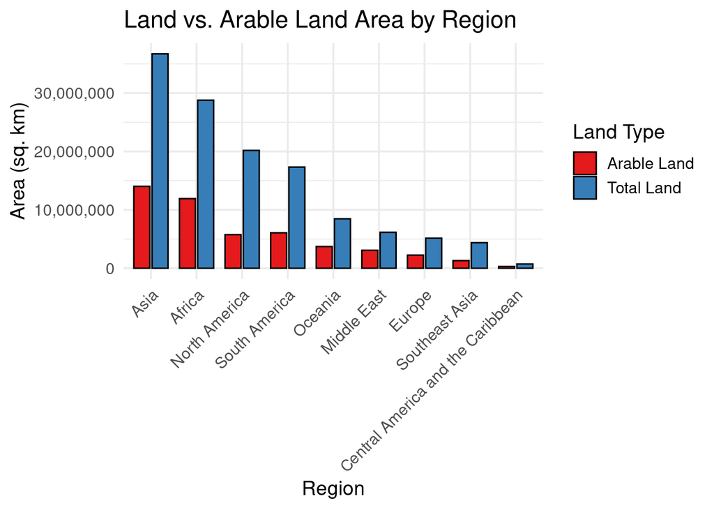

```r
# Combination of maps code
create_combined <- function(map, boxplot) {
  tagList(
    tags$div(
      style = "
        display: flex;
        gap: 20px;
        height: 600px;
        align-items: stretch;
        max-width: 100%;"
      ,
      tags$div(style = "flex: 1; height: 100%;", map),
      tags$div(style = "flex: 1.8; height: 100%;", boxplot)
    )
  )
}
# Land per continent
continent_land <- trim_df %>%
  group_by(Continent) %>%
  summarise(TotalLand = sum(Land.sqkm, na.rm = TRUE))

  # Arable land per continent
continent_arable_land <- trim_df %>%
  mutate(ArableLand = (Arable.land.percent) * Land.sqkm) %>%
  group_by(Continent) %>%
  summarise(TotalArableLand = sum(ArableLand, na.rm = TRUE))

# Combine into long format
combined <- left_join(continent_land, continent_arable_land, by="Continent") %>%
  pivot_longer(cols = c(TotalLand, TotalArableLand),
               names_to = "Type",
               values_to = "Area") %>%
  mutate(Type = recode(Type,
                       TotalLand = "Total Land",
                       TotalArableLand = "Arable Land"))

# Sort
continent_order <- combined %>%
  filter(Type == "Total Land") %>%
  arrange(desc(Area)) %>%
  pull(Continent)


combined$Continent <- factor(combined$Continent, levels=continent_order)

# Plot - skqm of land and arable land
ggplot(combined, aes(x = Continent, y = Area, fill = Type)) +
  geom_bar(stat = "identity", position = position_dodge(width=0.8), width = 0.7, color = "black") +
  scale_y_continuous(labels= comma) +
  labs(
    title = "Land vs. Arable Land Area by Region",
    x = "Region",
    y = "Area (sq. km)",
    fill = "Land Type"
  ) +
  theme_minimal(base_size=14) +
  theme(axis.text.x = element_text(angle = 45, hjust=1)) +
  scale_fill_brewer(palette="Set1")
```

```r
Box_GDP_Cap
```

[interactive chart not shown]

```r
Box_IMR
```

[interactive chart not shown]

```r
Box_Life_Expect
```

[interactive chart not shown]

```r
Box_Death_Rate
```

[interactive chart not shown]

```r
Box_Birth_Rate
```

[interactive chart not shown]

```r
Box_Pop_Growth_Rate
```

[interactive chart not shown]

```r
Box_Total_Pop
```

[interactive chart not shown]

```r
Box_Arable_Prop
```

[interactive chart not shown]

```r
Box_Total_Land
```

[interactive chart not shown]

```r
Map_GDP_Cap
```

[interactive chart not shown]

```r
Map_Arable_Land
```

[interactive chart not shown]

```r
Map_Birth_Rate
```

[interactive chart not shown]

```r
Map_Death_Rate
```

[interactive chart not shown]

```r
htmltools::browsable(create_combined(Map_GDP_Cap, Box_GDP_Cap))
```

[interactive chart not shown]

```r
numeric_df <- trim_df[, c("Total.sqkm", "Arable.land.percent", "Real.GDP.per.capita.USD", "Infant.deaths.per.1000.live.births", "Life.expectancy.at.birth", "Deaths.per.1000.people", "Live.births.per.1000.people", "Population.growth.rate.percent", "Total.population")]

pca_result <- prcomp(na.omit(numeric_df), center=TRUE, scale. = TRUE)

summary(pca_result)
```

```
## Importance of components:
##                           PC1    PC2    PC3     PC4     PC5     PC6     PC7
## Standard deviation     2.0078 1.2235 1.0883 0.89968 0.76476 0.71107 0.49098
## Proportion of Variance 0.4479 0.1663 0.1316 0.08994 0.06498 0.05618 0.02678
## Cumulative Proportion  0.4479 0.6142 0.7458 0.83578 0.90076 0.95694 0.98372
##                            PC8     PC9
## Standard deviation     0.27582 0.26533
## Proportion of Variance 0.00845 0.00782
## Cumulative Proportion  0.99218 1.00000
```

```r
raw_variance <- pca_result$sdev^2

pve <- raw_variance / sum(raw_variance)

cumulative_pve = cumsum(pve)

pca_performance_data <- data.frame(
  PC = factor(1:length(pve), levels = 1:length(pve)),
  RawVariance = raw_variance,
  PVE = pve,
  CumulativePVE = cumulative_pve
)
```

PCA Variances Plot:

Cumulative Proportion of Variance Explained (CPVE) plot:

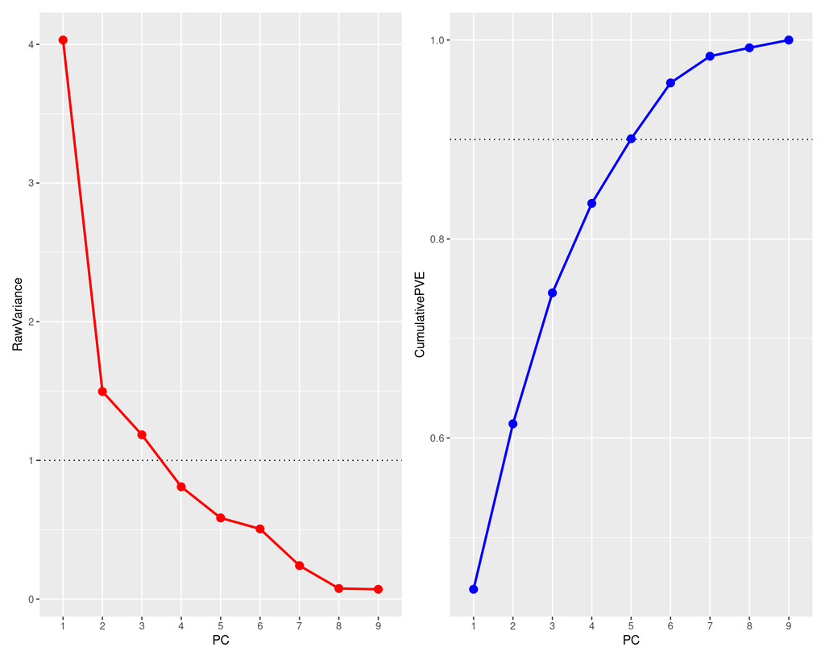

```r
raw_var_plot + cpve_plot
```

There are 3 principal components that “aggregate information” due to the variance being larger than 1 while the PCA was run on scaled data. Additionally, to capture ~90% of the variance, we nned 5 PCs.

Here we plot the loading vectors of the PCA on the axes of the first and second principal components.

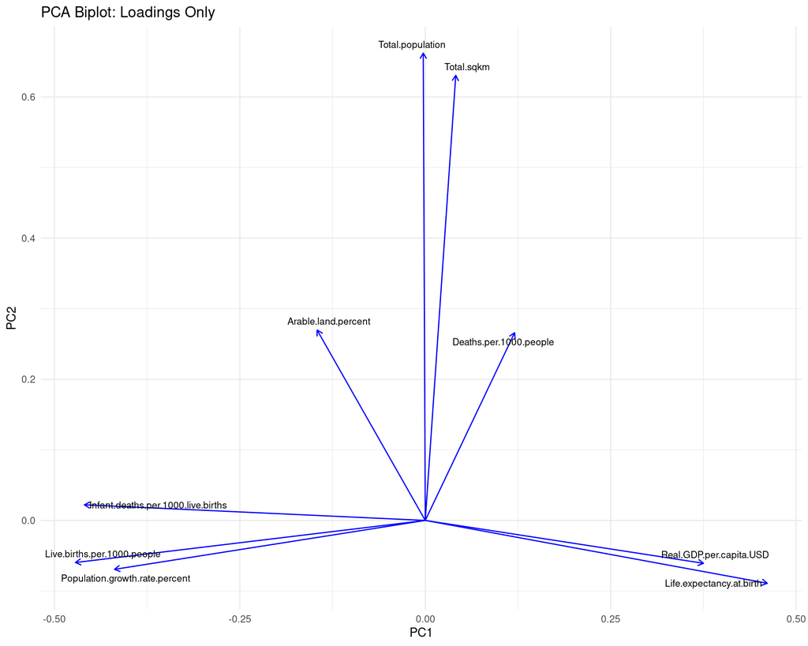

```r
# Create dataframe for loadings
loadings_df <- as.data.frame(pca_result$rotation[, 1:2])
loadings_df$varname <- rownames(loadings_df)

ggplot(loadings_df, aes(x = PC1, y = PC2)) +
  geom_segment(aes(x = 0, y = 0, xend = PC1, yend = PC2),
               arrow = arrow(length = unit(0.2,"cm")), color = "blue") +
  geom_text_repel(aes(label = varname), size = 3, max.overlaps = 100) +
  labs(title = "PCA Biplot: Loadings Only") +
  theme_minimal()
```

One can see that for small values of PC1 we see large values of Infant Mortality Rate, Birth Rate, and Population Growth Rate. For large values of PC1 we see large values of Real GDP per capita USD and Life Expectancy at Birth. One could interpret PC1 as the developedness of countries with larger values corresponding to more developed countries.

For large values of PC2 we see that the countries typically have large values of Total Poplation and Total SqKm ans also (to a lesser degree) Arable Land and Death Rate. PC2 could be interpreted as the size of a country in terms of population and area.

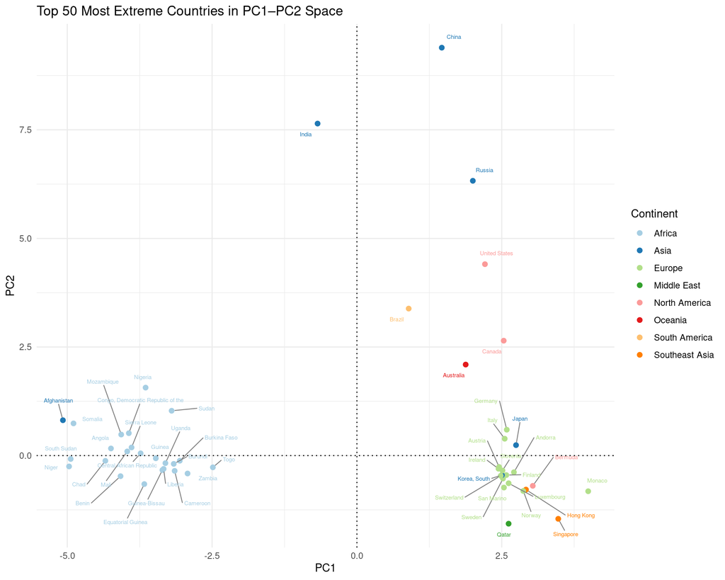

```r
meta_df <- trim_df[, c("Country", "Continent")]
# Get PCA scores (observations)
scores_df <- as.data.frame(pca_result$x[, 1:2])
scores_df$Country <- rownames(scores_df)

# Add distance from origin in PC1-PC2 space
scores_df <- scores_df %>%
  left_join(meta_df, by = "Country") %>%
  mutate(Distance = sqrt(PC1^2 + PC2^2))

# Keep top 10 extreme countries - euclidean norm of first two principal components
top_extremes <- scores_df %>%
  arrange(desc(Distance)) %>%
  slice_head(n = 50)



# Plot
ggplot(top_extremes, aes(x = PC1, y = PC2, label = Country, color = Continent)) +
  geom_point(size = 2) +
  geom_text_repel(
    size = 2,
    max.overlaps = Inf,        # allow all to be plotted
    force = 2,                 # increase repulsion strength
    force_pull = 0.1,          # balance between point and label
    box.padding = 0.5,         # more space around text
    point.padding = 0.3,       # space between text and point
    segment.color = "grey50",  # optional connector color
    segment.size = 0.4
  ) +
  geom_hline(yintercept=0, linetype="dotted", color="black") +
  geom_vline(xintercept=0, linetype="dotted", color="black") +
  labs(title = "Top 50 Most Extreme Countries in PC1–PC2 Space",
       x = "PC1", y = "PC2") +
  theme_minimal() +
  scale_color_brewer(palette = "Paired")
```

We see groupings along the PC1 axis of more developed countries on the side with larger PC1 values and less developed countries with smaller PC1 values. There are several outliers with large values for PC2 that correspond with larger countries in terms of both population and land mass.

```r
Box_PC1 <- plot_boxplot_with_points(scores_df, "PC1", title="PC1 (Developedness)", y_label="PC1", x_label="Region")
Box_PC2 <- plot_boxplot_with_points(scores_df, "PC2", title="PC2 (Size)", y_label="PC2", x_label="Region")
Box_PC1
```

[interactive chart not shown]

```r
Box_PC2
```

[interactive chart not shown]